# CP-2007: Análisis Político Cuantitativo 2

## Análisis de correlación y regresión

### Exploración de datos e inspección visual

Como ocurre con todos los análisis estadísticos, el primer paso y el más importante es explorar nuestros datos. Queremos tener una idea no solo de la distribución de los datos, sino también de verificar observaciones potencialmente extrañas, que pueden ser el resultado de errores de codificación. Primero, observemos el termómetro de variable dependiente.

```r
# estadísticas descriptivas de la variable
summary(thermometer)
```

```
##    Min. 1st Qu.  Median    Mean 3rd Qu.    Max.
##   33.48   52.65   58.13   58.75   66.68   83.48
```

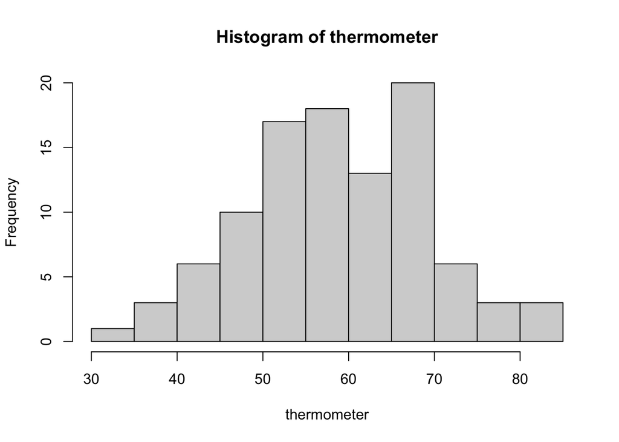

```r
# un plot del histograma de la variable
hist(thermometer)
```

```r
#se calcula la densidad de la variable
d_therm <- density(thermometer)
head(d_therm)
```

[output not shown]

[output cut: 167 more lines]

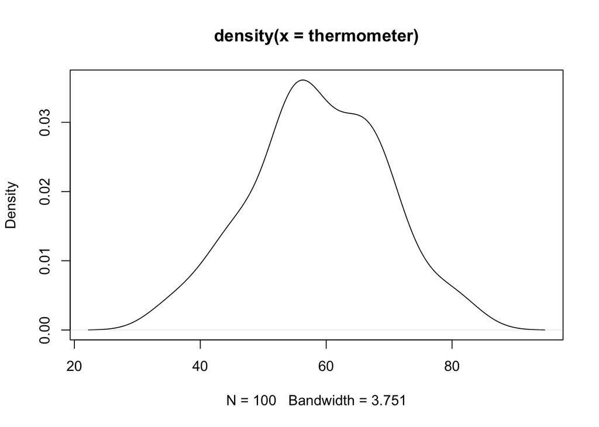

```r
#plot de la densidad que es más claro que el histograma
plot(d_therm)
```

Nada extraño aquí, la variable dependiente tiende a una distribución normal con una media alrededor de 58. Podríamos hacer esto individualmente para todas las variables en nuestro conjunto de datos, pero esto a veces no es práctico. Podemos ver todas nuestras variables a la vez usando algunos de los comandos anteriores y el paquete de gráficos ggplot2.

```r
# Esto hace un resumen de todas las variables del dataframe
summary(mayor)
```

```
##   thermometer         age           college         income
##  Min.   :33.48   Min.   :12.00   Min.   :0.00   Min.   :0.1308
##  1st Qu.:52.65   1st Qu.:35.50   1st Qu.:0.00   1st Qu.:1.1096
##  Median :58.13   Median :45.00   Median :0.00   Median :1.8562
##  Mean   :58.75   Mean   :44.21   Mean   :0.28   Mean   :1.9668
##  3rd Qu.:66.68   3rd Qu.:51.00   3rd Qu.:1.00   3rd Qu.:2.7760
##  Max.   :83.48   Max.   :74.00   Max.   :1.00   Max.   :4.8085
```

```r
library(reshape2)   #este paquete transforma los datos de formato " from wide"ancho" a lo "largo"
library(ggplot2)    # paquete para gráficos

# Se repasa la estructura del DF
head(mayor)
```

```
##   thermometer age college    income
## 1    56.34649  43       0 2.4427731
## 2    35.97210  74       0 3.1663986
## 3    67.54335  14       0 3.2047044
## 4    66.99035  49       1 1.1211726
## 5    68.79006  22       0 0.2223342
## 6    67.41089  40       1 2.2907541
```

```r
# melt invierte el formato ancho (wide-format) en largo (long-format) de los datos.
d <- melt(mayor)
head(d)
```

```
##      variable    value
## 1 thermometer 56.34649
## 2 thermometer 35.97210
## 3 thermometer 67.54335
## 4 thermometer 66.99035
## 5 thermometer 68.79006
## 6 thermometer 67.41089
```

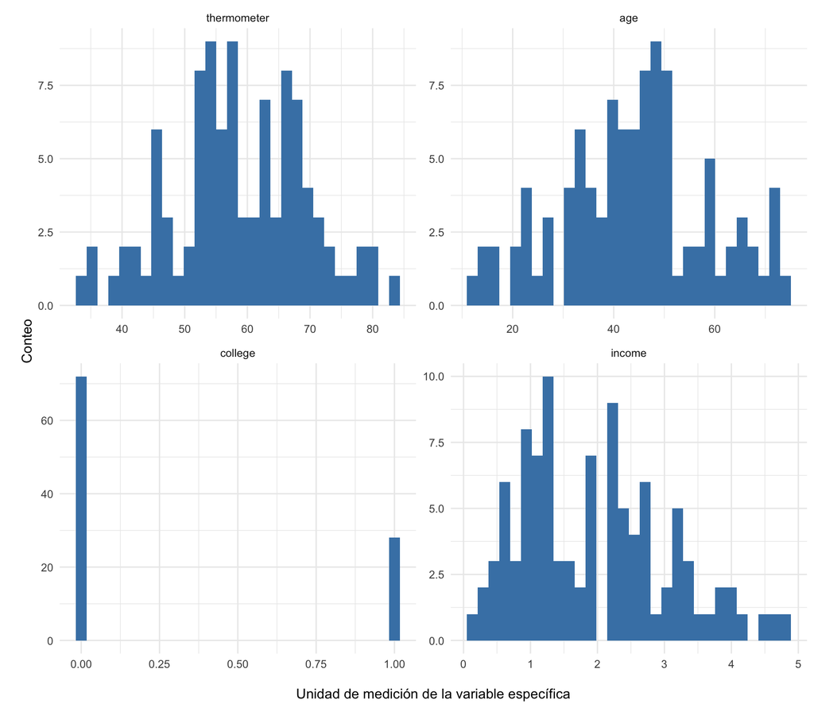

```r
# Se hace le gráfico por capas:

# se graficas los datos "d"
ggplot(d, aes(x = value)) +
  # Se hace un gráfico de facetas (mini-gráficos), y escalas
  facet_wrap(~variable, scales = "free") +
  # se especifica el geométrico
  geom_histogram(fill="steelblue") +
  labs(y="\nConteo", x="\nUnidad de medición de la variable específica\n") +
  theme_minimal()
```

Estos gráficos proporcionan una inspección visual de los datos. Podemos ver que el termómetro se mueve entre los límites de 30 y 90. La edad entre 15 y 80, ingresos entre 0 y 5 (recuerde que esto es en miles de dólares) y casi 70 observaciones no tienen universidad.

### Correlación

Antes de proceder con análisis más sofisticados, a menudo es útil inspeccionar la correlación entre variables. Eso es muy útil y recomendado como paso previo a la regresión. Una forma de hacerlo de manera eficiente es obteniendo una matriz de correlación, que muestra cómo las variables se mueven juntas. Una forma fácil de hacer esto es usando el paquete corrplot:

```r
library(corrplot)

# Se calcula la matriz de correlaciones que llamamos "M"
M <- cor(mayor)

# Se imprime toda la matriz porque es pequeña
print(M)
```

```
##             thermometer        age    college     income
## thermometer   1.0000000 -0.6805495  0.5946719 -0.3910551
## age          -0.6805495  1.0000000  0.1107140  0.1999083
## college       0.5946719  0.1107140  1.0000000 -0.0930378
## income       -0.3910551  0.1999083 -0.0930378  1.0000000
```

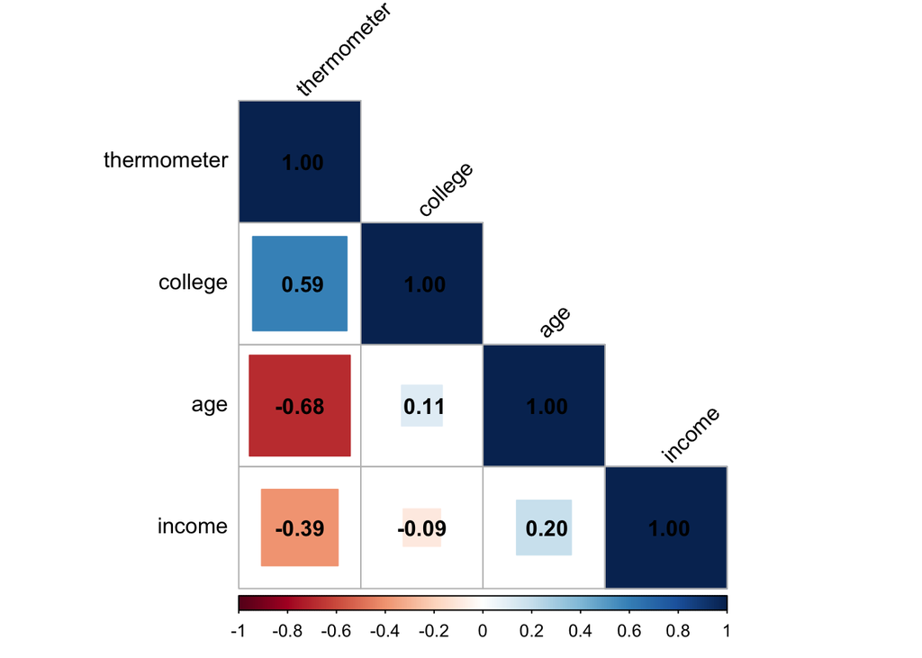

```r
# Se usan cuadrados para el gráfico: method="square". Ojo que la matriz gráfica solo toma en cuenta la mitad.
corrplot(M, method="square",
         type="lower",
         order="hclust",
         tl.col="black",
         tl.srt=45,
         addCoef.col = TRUE)
```

### Regresión “a la media”

Tenemos la intención de hacer una regresión de nuestra variable dependiente `termómetro`, con una serie de predictores. R es un software basado en objetos, que asigna valores a los objetos, que luego podemos resumir. Para ejecutar una regresión, por lo tanto, tenemos que asignar un modelo de regresión lineal a un objeto. La función `lm` se especifica como tal: `lm (respuesta ~ predictor_1 + predictor_2 ... + predictor_n)`. Entonces, en nuestro caso, podemos especificar al menos tres modelos de complejidad creciente:

```r
# TRES MODELOS

# Regresión de termómetro con edad
linear.model.1 <- lm(formula=thermometer ~ age, data=mayor)


# Regresión de termómetro con edad + universidad
linear.model.2 <- lm(formula=thermometer ~ age + college, data=mayor)


# Regresión de termómetro con edad + universidad + ingreso
linear.model.3 <- lm(formula=thermometer ~ age + college + income, data=mayor)
```

Con `summary` se puede obtener el resultado detallado de cada modelo de regresión.

```r
# Modelo 1
summary(linear.model.1)
```

```
##
## Call:
## lm(formula = thermometer ~ age, data = mayor)
##
## Residuals:
##     Min      1Q  Median      3Q     Max
## -14.129  -5.343  -2.420   7.237  19.091
##
## Coefficients:
##             Estimate Std. Error t value Pr(>|t|)
## (Intercept) 80.90042    2.53222  31.948  < 2e-16 ***
## age         -0.50107    0.05449  -9.195 6.77e-15 ***
## ---
## Signif. codes:  0 '***' 0.001 '**' 0.01 '*' 0.05 '.' 0.1 ' ' 1
##
## Residual standard error: 7.796 on 98 degrees of freedom
## Multiple R-squared:  0.4631, Adjusted R-squared:  0.4577
## F-statistic: 84.55 on 1 and 98 DF,  p-value: 6.766e-15
```

```r
# Modelo 2
summary(linear.model.2)
```

```
##
## Call:
## lm(formula = thermometer ~ age + college, data = mayor)
##
## Residuals:
##     Min      1Q  Median      3Q     Max
## -8.6889 -1.8682  0.3394  2.1866  7.6208
##
## Coefficients:
##             Estimate Std. Error t value Pr(>|t|)
## (Intercept) 78.88907    1.00068   78.83   <2e-16 ***
## age         -0.55637    0.02159  -25.77   <2e-16 ***
## college     15.91407    0.68783   23.14   <2e-16 ***
## ---
## Signif. codes:  0 '***' 0.001 '**' 0.01 '*' 0.05 '.' 0.1 ' ' 1
##
## Residual standard error: 3.069 on 97 degrees of freedom
## Multiple R-squared:  0.9176, Adjusted R-squared:  0.9159
## F-statistic: 540.4 on 2 and 97 DF,  p-value: < 2.2e-16
```

```r
# Modelo 3
summary(linear.model.3)
```

```
##
## Call:
## lm(formula = thermometer ~ age + college + income, data = mayor)
##
## Residuals:
##     Min      1Q  Median      3Q     Max
## -5.3957 -1.7177 -0.1198  1.7001  7.4953
##
## Coefficients:
##             Estimate Std. Error t value Pr(>|t|)
## (Intercept) 81.27935    0.83337  97.531  < 2e-16 ***
## age         -0.52709    0.01718 -30.678  < 2e-16 ***
## college     15.40291    0.53874  28.590  < 2e-16 ***
## income      -1.80067    0.22446  -8.022 2.55e-12 ***
## ---
## Signif. codes:  0 '***' 0.001 '**' 0.01 '*' 0.05 '.' 0.1 ' ' 1
##
## Residual standard error: 2.387 on 96 degrees of freedom
## Multiple R-squared:  0.9507, Adjusted R-squared:  0.9492
## F-statistic:   617 on 3 and 96 DF,  p-value: < 2.2e-16
```

Hay otros paquetes que dan los mismos resultados pero de forma más ordenada y clara para la interpretación. Incluso de forma comparativa como los disponibles del paquete `jtools` (recuerde instalarlo primero). Con este paquete se puede estandarizar los coeficientes a unidades de desviación estándar con el parámetro `scales = TRUE`. Veámos un par de ejemplos.

### Tabla comparada

```r
library(jtools)

# gráfico comparado
export_summs(linear.model.1,
             linear.model.2,
             linear.model.3,
             model.names=c("modelo 1", "modelo 2", "modelo 3"), statistics = "all")
```

|  | modelo 1 | modelo 2 | modelo 3 |
| --- | --- | --- | --- |
| (Intercept) | 80.90 *** | 78.89 *** | 81.28 *** |
|  | (2.53) | (1.00) | (0.83) |
| age | -0.50 *** | -0.56 *** | -0.53 *** |
|  | (0.05) | (0.02) | (0.02) |
| college |  | 15.91 *** | 15.40 *** |
|  |  | (0.69) | (0.54) |
| income |  |  | -1.80 *** |
|  |  |  | (0.22) |
| nobs | 100 | 100 | 100 |
| r.squared | 0.46 | 0.92 | 0.95 |
| adj.r.squared | 0.46 | 0.92 | 0.95 |
| sigma | 7.80 | 3.07 | 2.39 |
| statistic | 84.55 | 540.40 | 617.03 |
| p.value | 0.00 | 0.00 | 0.00 |
| df | 1.00 | 2.00 | 3.00 |
| logLik | -346.25 | -252.52 | -226.87 |
| AIC | 698.50 | 513.04 | 463.73 |
| BIC | 706.32 | 523.46 | 476.76 |
| deviance | 5956.92 | 913.83 | 547.08 |
| df.residual | 98.00 | 97.00 | 96.00 |
| nobs.1 | 100.00 | 100.00 | 100.00 |
| *** p < 0.001; ** p < 0.01; * p < 0.05. |  |  |  |

La tabla muestra los tres modelos de forma comparada. Acá es importante identificar una serie de indicadores para la interpretación de la regresión. Ver lecturas de Gómez (2016) y Gujarati (2011) para repasar estos conceptos:

1. ¿Cuáles variables son significativas? Se denota con asteriscos las variables idependientes (predictores) que tienen resultados significativos estadísticamente. Esos son los casos donde la relación de asociación fue relevante.
2. ¿Cuál es la dirección de esa relación? El signo de los coeficientes identifica si es una relación positiva o si es negativa.
3. ¿Cuán robusto es nuestro modelo estadístico? Eso se obtiene con el `r.squared`. Cuando los modelos tienen múltiples variables predictoras se debe interpretar el `adj.r.squared` porque considera los grados de libertad de acuerdo con la cantidad de variables incluidas en el modelo.

### Tabla comparada estandarizada

Al agregar `scales = TRUE`, se estandarizan los coeficientes a unidades de desviación estándar.

```r
library(jtools)

# gráfico comparado
export_summs(linear.model.1,
             linear.model.2,
             linear.model.3,
             model.names=c("modelo 1", "modelo 2", "modelo 3"), scale = TRUE, statistics = "all")
```

|  | modelo 1 | modelo 2 | modelo 3 |
| --- | --- | --- | --- |
| (Intercept) | 58.75 *** | 54.29 *** | 54.44 *** |
|  | (0.78) | (0.36) | (0.28) |
| age | -7.20 *** | -8.00 *** | -7.58 *** |
|  | (0.78) | (0.31) | (0.25) |
| college |  | 15.91 *** | 15.40 *** |
|  |  | (0.69) | (0.54) |
| income |  |  | -1.98 *** |
|  |  |  | (0.25) |
| nobs | 100 | 100 | 100 |
| r.squared | 0.46 | 0.92 | 0.95 |
| adj.r.squared | 0.46 | 0.92 | 0.95 |
| sigma | 7.80 | 3.07 | 2.39 |
| statistic | 84.55 | 540.40 | 617.03 |
| p.value | 0.00 | 0.00 | 0.00 |
| df | 1.00 | 2.00 | 3.00 |
| logLik | -346.25 | -252.52 | -226.87 |
| AIC | 698.50 | 513.04 | 463.73 |
| BIC | 706.32 | 523.46 | 476.76 |
| deviance | 5956.92 | 913.83 | 547.08 |
| df.residual | 98.00 | 97.00 | 96.00 |
| nobs.1 | 100.00 | 100.00 | 100.00 |
| All continuous predictors are mean-centered and scaled by 1 standard deviation. The outcome variable is in its original units. *** p < 0.001; ** p < 0.01; * p < 0.05. |  |  |  |

### Tabla estandarizada 1 modelo

```r
library(jtools)

# gráfico comparado
export_summs(linear.model.3, scale = TRUE, statistics = "all")
```

|  | Model 1 |
| --- | --- |
| (Intercept) | 54.44 *** |
|  | (0.28) |
| age | -7.58 *** |
|  | (0.25) |
| college | 15.40 *** |
|  | (0.54) |
| income | -1.98 *** |
|  | (0.25) |
| nobs | 100 |
| r.squared | 0.95 |
| adj.r.squared | 0.95 |
| sigma | 2.39 |
| statistic | 617.03 |
| p.value | 0.00 |
| df | 3.00 |
| logLik | -226.87 |
| AIC | 463.73 |
| BIC | 476.76 |
| deviance | 547.08 |
| df.residual | 96.00 |
| nobs.1 | 100.00 |
| All continuous predictors are mean-centered and scaled by 1 standard deviation. The outcome variable is in its original units. *** p < 0.001; ** p < 0.01; * p < 0.05. |  |

También podemos graficar un aspecto de los puntajes del termómetro dados algunos de los predictores. Hagamos esto para el termómetro y la edad del primer modelo.

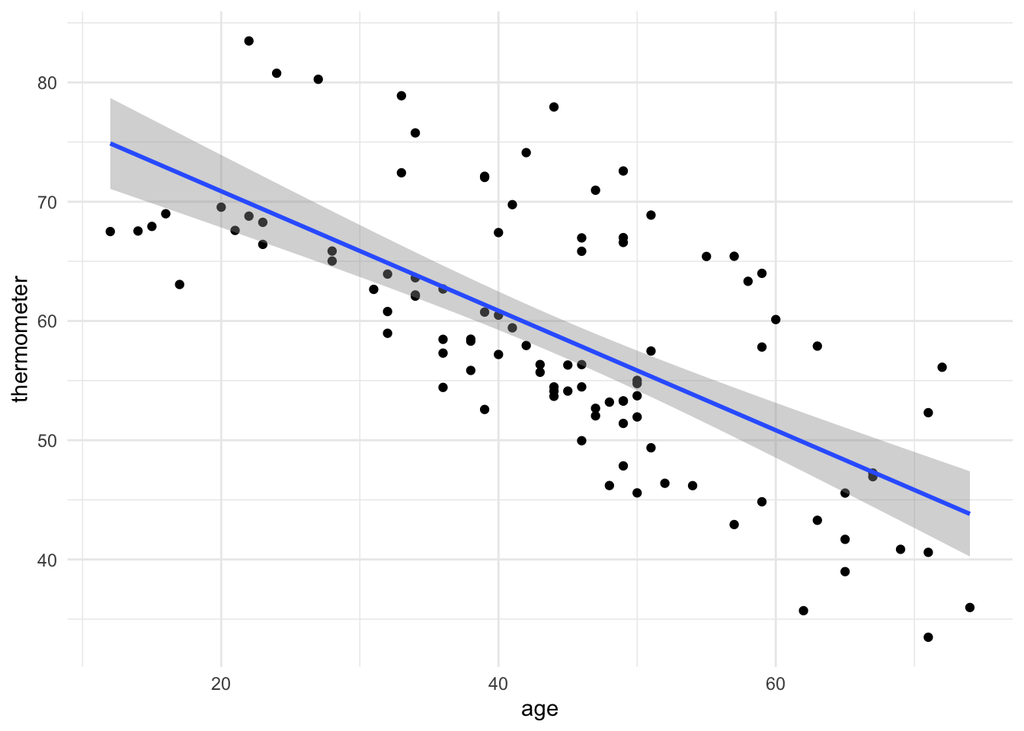

```r
# Usando ggplot
ggplot(mayor, aes(x=age, y=thermometer)) +
  geom_point() + # agrega los puntos de las observaciones
  geom_smooth(method=lm, aes(fill=age)) + # calcula la línea de regresión con base en la variable "age"
  theme_minimal() # tema de formato del gráfico
```

Como puede verse en esta figura, a medida que aumenta la edad, la puntuación del termómetro tiende a bajar. La línea de regresión se ajusta bastante bien a esta relación. Supongamos ahora que queremos investigar esta relación, pero queremos investigar si hay diferencias para las personas con educación universitaria. Esto también se hace fácilmente para dos predictores, pero usando las funciones de graficaciones básicas de R.

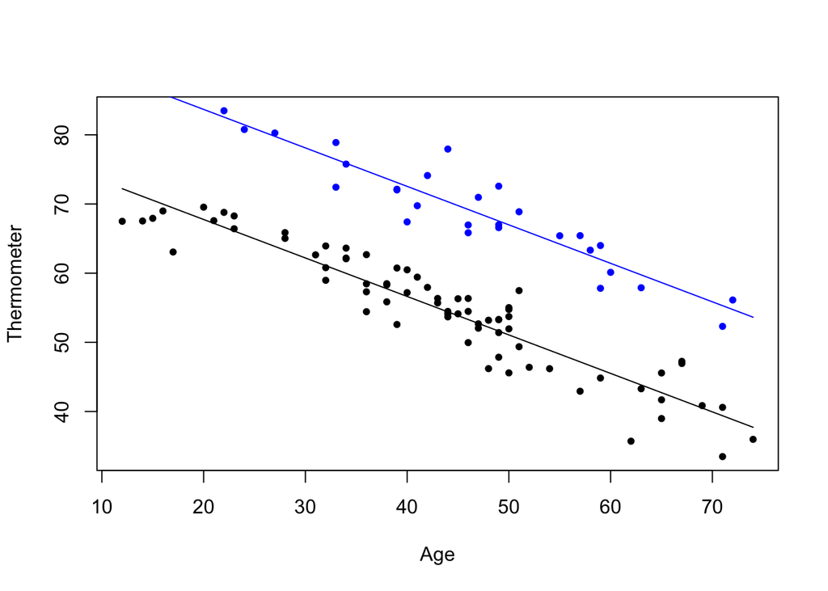

```r
# gráfico usando el paquete base de R
colors<-ifelse(college==1, "blue", "black") # Se definen los colores
plot(age, thermometer, xlab="Age",ylab ="Thermometer", col=colors, pch=20) # datos a graficar
curve (cbind(1,x,1) %*% coef(linear.model.2), add=TRUE, col="blue") # línea de regresión del modelo 2 para universidad (en azul)
curve (cbind(1,x,0) %*% coef(linear.model.2), add=TRUE, col="black") # línea de regresión del modelo 2 para edad (en negro)
```

Finalmente podemos visualizar los coeficientes de varios modelos a la vez e interpretar fácilmente con la función `plot_summs` del paquete `jtools` de la siguiente forma.

Igual que en la tabla anterior, se puede hacer el gráfico con los coeficientes del modelo, en las unidades de medición específica de cada una, o bien se puede graficar el modelo con los coeficientes estandarizados `scale = TRUE`.

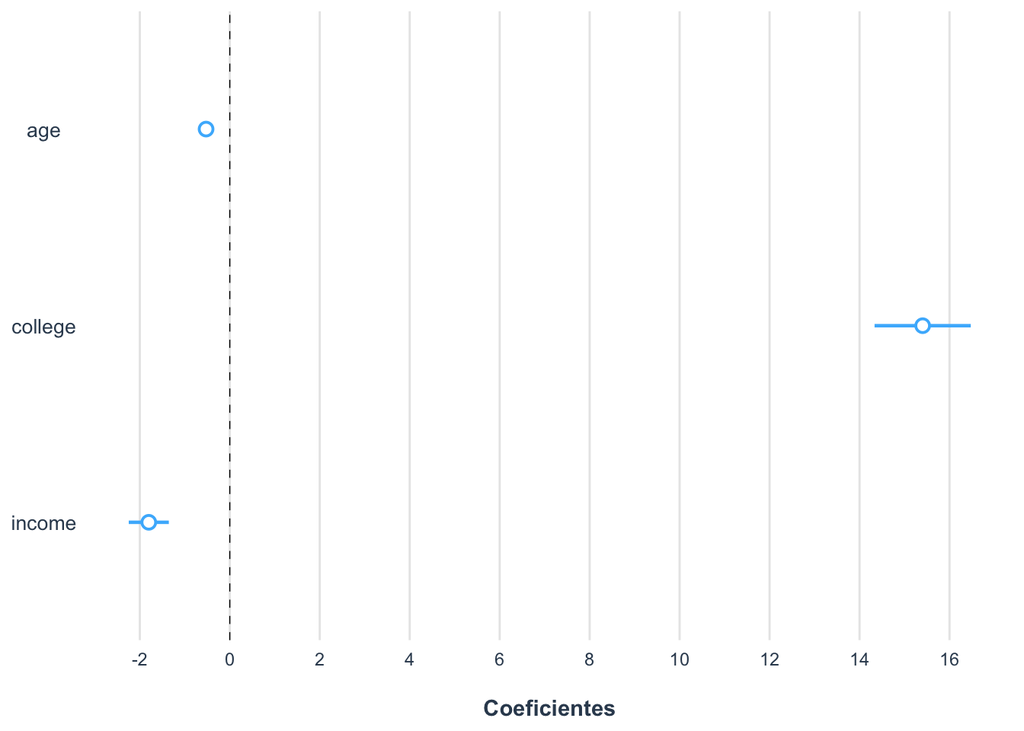

```r
# Modelo completo
plot_summs(linear.model.3) +
  labs(x= "\nCoeficientes", y="") +
  scale_x_continuous(breaks = seq(-2,16,2))
```

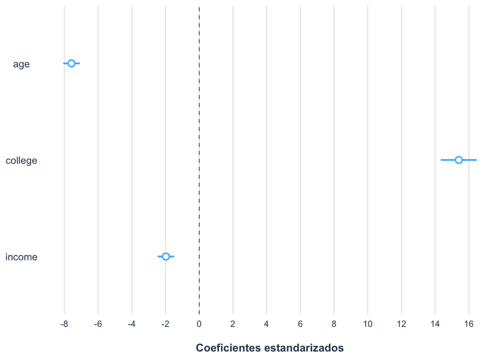

```r
# Modelo completo estandarizado: scale = TRUE (convierte a z-score/dev.estand)
plot_summs(linear.model.3, scale = TRUE) +
  labs(x= "\nCoeficientes estandarizados", y="") +
  scale_x_continuous(breaks = seq(-8,16,2))
```

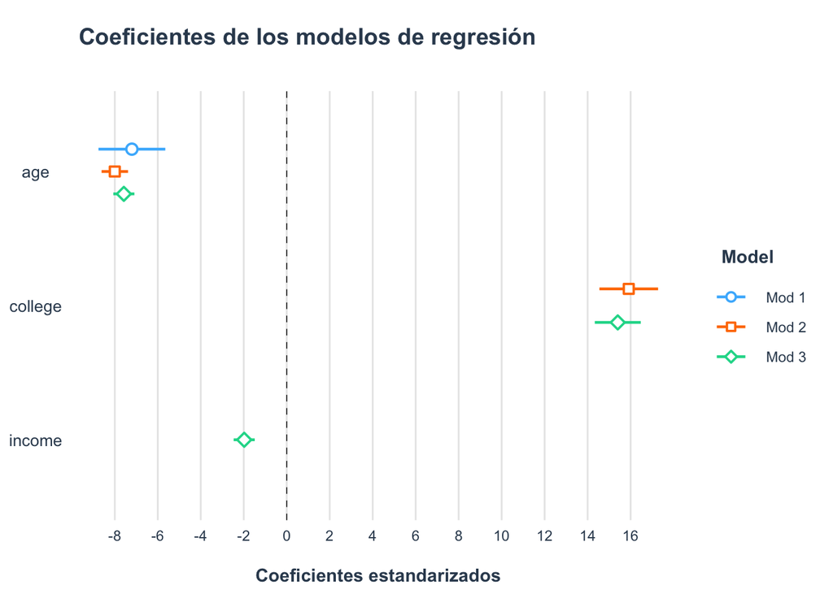

```r
# Modelos comparados
plot_summs(linear.model.1,linear.model.2,linear.model.3,
           model.names=c("Mod 1", "Mod 2", "Mod 3"),
           scale = TRUE) +
  labs(x= "\nCoeficientes estandarizados", y="", title = "Coeficientes de los modelos de regresión\n") +
  scale_x_continuous(breaks = seq(-8,16,2))
```

# Bibliografía de referencia

Achen, C. H. (1982). Interpreting and using regression. Newbury Park: Sage.

Box-Steffensmeier, J. M., Brady, H. E., y Collier, D. (2008). The Oxford Handbook of Political Methodology. New York: Oxford University Press.

Camarero, L. et.al. sf. Regresión Logística: Fundamentos y aplicación a la investigación sociológica. Departamento de Sociología I, UNED. España.

Cardona, D. et.al. 2013. Inferencia estadística módulo de regresión lineal simple /Bogotá: Editorial Universidad del Rosario, Escuela de Administración.

Demeusy, A (2023). Pearson correlation: Methodology, Limitations & Alternatives — Part 1 : Methodology. En: https://medium.com/@anthony.demeusy/pearson-correlation-methodology-limitations-alternatives-part-1-methodology-42abe8f1ba90.

Gómez, M. (2016). Elementos de estadística descriptiva. San José: Universidad Estatal a Distancia.

Gujarati, D. N., y Porter, D. C. (2011). Econometría Básica. México: McGraw Hill.

Huff, D. 2015. Cómo mentir con estadísticas. Barcelona: Ares y Mares.

Kim, J. O., Mueller, C. W. (1978). Introduction to factor analysis: What it is and how to do it. Newbury Park: Sage.

King, G., Keohane, R. O., y Verba, S. (1994). Designing social inquiry: Scientific inference in qualitative research.Princeton: Princeton University Press.

Levin, J. (1999). Fundamentos de estadística en la investigación social. Oxford: Oxford University Press.

Lewis-Beck, M. (2015). Applied regression: An introduction. Newbury Park: Sage.

Manheim, J., Ritch, R. (1988). Análisis político empírico: métodos de investigación en ciencia política. Madrid: Alianza Universidad Textos.

Ritchey, F. J. (2002). Estadística para las ciencias sociales: el potencial de la imaginación estadística. México: McGraw-Hill Interamericana Editores, S.A.

Vargas, T.R. (2016). Linear Regression for Politics. En: https://rstudio-pubs-static.s3.amazonaws.com/202558_b017a3e4cb7442a4aafb4a5737fd5545.html